# Week 10 — ML Fundamentals

[Open in Colab](https://colab.research.google.com/github/sanketn26/learn-ml/blob/main/notebooks/week-10-saas.ipynb) [Open in VS Code](https://vscode.dev/github/sanketn26/learn-ml/blob/main/notebooks/week-10-saas.ipynb) Open in Jupyter [Download .ipynb](https://raw.githubusercontent.com/sanketn26/learn-ml/main/notebooks/week-10-saas.ipynb)

### 📝 How to Run This Notebook Locally

**1. Clone the repository:**  
`git clone https://github.com/sanketn26/learn-ml.git && cd learn-ml`

**2. Set up environment:**  
`python3 -m venv venv && source venv/bin/activate`  
`pip install jupyter notebook`

**3. Install course dependencies:**  
`pip install numpy pandas scikit-learn matplotlib scipy seaborn`  
`pip install torch`

**4. Open the notebook:**  
`jupyter notebook notebooks/week-10-saas.ipynb`

# Week 10 — Ensembles: A Room of Reviewers

**Course:** Applied ML Foundations for SaaS Analytics  
**Who this is for:** Engineers who have run a design review or a CI matrix. Same idea: one opinion is brittle.

## 🎯 What you will be able to do

- Separate **bagging**, **boosting**, **voting**, and **stacking** (they are not synonyms)
- Default to a forest / gradient-boosted trees for tabular SaaS data
- Read a learning-rate × n_estimators heatmap
- Know when a committee is worth the ops cost

**Think of it like… code review.**

**Bagging** (Random Forest): several reviewers read *different random pages* of the PR and vote. Uncorrelated mistakes cancel. Good at calming a jittery model.  
**Boosting** (Gradient Boosting / XGBoost): reviewer 2 is handed only the comments reviewer 1 missed, then reviewer 3 hunts what 2 missed. Great at squeezing the last points. Easier to overfit.  
**Voting**: different algorithms (linear + forest + booster) cast a vote tonight.  
**Stacking**: a second model learns *how to listen* to those votes. Not the same as voting.

**Laptop budget**

No GPU. Aimed at ~8 GB RAM. Training uses a few thousand sampled customers (or short sequences) so this notebook should finish in a **few minutes on CPU**. The ideas are the same if you later set `n=None` and train on all 50k rows.

```python
%matplotlib inline
from pathlib import Path
import sys

import numpy as np
import pandas as pd
import matplotlib.pyplot as plt

# Make the shared style kit importable whether you launch from notebooks/ or repo root
for _p in [Path.cwd(), Path.cwd() / "notebooks", Path.cwd().parent]:
    if (_p / "course_style.py").exists():
        sys.path.insert(0, str(_p))
        break

from course_style import apply_style, setup_plots, find_data_dir

apply_style()
setup_plots()
DATA = find_data_dir()
print(f"Data folder: {DATA}")
print("Laptop mode: no GPU required. Models use a sample so each week finishes in a few minutes on CPU.")

from sklearn.model_selection import train_test_split
from sklearn.preprocessing import StandardScaler, OneHotEncoder
from sklearn.compose import ColumnTransformer
from sklearn.pipeline import Pipeline
from sklearn.linear_model import LogisticRegression
from sklearn.ensemble import (RandomForestClassifier, GradientBoostingClassifier,
                              VotingClassifier)
from sklearn.metrics import roc_auc_score
from sklearn.model_selection import validation_curve
```

```
Data folder: /Users/sanketnaik/workspace/learn-ml/data
Laptop mode: no GPU required. Models use a sample so each week finishes in a few minutes on CPU.
```

## Picture the two committees

```
BAGGING                         BOOSTING
 data ─┬─► tree ─┐               data ─► tree1 ─ misses ─► tree2 ─ misses ─► tree3
       ├─► tree ─┼─ vote                           ↘ add ↗         ↘ add ↗
       └─► tree ─┘               final = tree1 + tree2 + tree3
```

**Engineer mental model**

For CloudWave-sized *tables* (thousands to hundreds of thousands of rows, mixed numbers + categories), **gradient-boosted trees are the default workhorse** — XGBoost / LightGBM / sklearn’s GBT. Neural nets start to win on images, text, and sequences, not on a 7-column billing table.

```python
from course_style import load_customer_360

df = load_customer_360(DATA)
numeric = ["mrr", "tenure_days", "log_usage", "features_adopted", "total_events", "n_support"]
X = df[numeric + ["plan_type"]]
y = df["is_churned"].astype(int)
X_train, X_test, y_train, y_test = train_test_split(
    X, y, test_size=0.2, random_state=42, stratify=y
)
prep = ColumnTransformer([
    ("num", StandardScaler(), numeric),
    ("cat", OneHotEncoder(handle_unknown="ignore"), ["plan_type"]),
])

def auc_of(model):
    p = Pipeline([("prep", prep), ("m", model)])
    p.fit(X_train, y_train)
    return p, roc_auc_score(y_test, p.predict_proba(X_test)[:, 1])

models = {
    "logreg": LogisticRegression(max_iter=1000),
    "forest (bagging)": RandomForestClassifier(n_estimators=40, max_depth=6, random_state=42, n_jobs=2),
    "gbt (boosting)": GradientBoostingClassifier(n_estimators=40, learning_rate=0.1, max_depth=2, random_state=42),
}
fitted = {}
print(f"{'model':<22} AUC")
for name, m in models.items():
    pipe, auc = auc_of(m)
    fitted[name] = pipe
    print(f"{name:<22} {auc:.3f}")
```

```
model                  AUC
logreg                 0.592
forest (bagging)       0.566
gbt (boosting)         0.587
```

## Soft voting ≠ stacking

Soft voting averages predicted probabilities. Stacking would train a *meta-model* on those probabilities. We will do voting honestly, and name it correctly.

```python
vote = VotingClassifier(
    estimators=[
        ("lr", LogisticRegression(max_iter=1000)),
        ("rf", RandomForestClassifier(n_estimators=30, max_depth=6, random_state=42, n_jobs=2)),
        ("gb", GradientBoostingClassifier(n_estimators=30, max_depth=2, random_state=42)),
    ],
    voting="soft",
)
vote_pipe, vote_auc = auc_of(vote)
print(f"soft voting AUC: {vote_auc:.3f}")
print("A 0.002 lift that costs 3× latency is usually not a win.")
```

[output not shown]

## The only hyperparameter picture you need this week

`learning_rate` is how hard each new tree is allowed to shove the answer. More trees + smaller steps ≈ same work, often stabler. There is no magic pair — there is a ridge on a heatmap.

[output not shown]

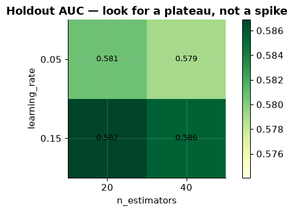

```python
rates = [0.05, 0.15]
trees = [20, 40]
grid = np.zeros((len(rates), len(trees)))
for i, lr in enumerate(rates):
    for j, n in enumerate(trees):
        _, grid[i, j] = auc_of(
            GradientBoostingClassifier(learning_rate=lr, n_estimators=n,
                                       max_depth=2, random_state=42)
        )

fig, ax = plt.subplots(figsize=(6.2, 3.6))
im = ax.imshow(grid, cmap="YlGn", vmin=grid.min() - 0.005, vmax=grid.max())
ax.set_xticks(range(len(trees)), trees)
ax.set_yticks(range(len(rates)), rates)
ax.set_xlabel("n_estimators"); ax.set_ylabel("learning_rate")
ax.set_title("Holdout AUC — look for a plateau, not a spike")
for i in range(grid.shape[0]):
    for j in range(grid.shape[1]):
        ax.text(j, i, f"{grid[i, j]:.3f}", ha="center", va="center", fontsize=9)
fig.colorbar(im, ax=ax, fraction=0.046)
plt.tight_layout()
plt.show()
```

## Bias–variance on purpose

Bagging (a forest) is a **variance reducer**: many jittery trees, averaged. Boosting is a **bias reducer**: each tree hunts what the last one still misses — and will overfit if you let it run forever.

The diagnostic is always the same pair of curves.

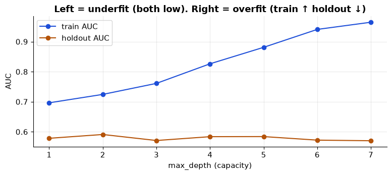

```
Pick the depth where orange peaks, not where blue is 1.0.
```

```python
from sklearn.model_selection import validation_curve

# 6k-row picture is enough to see the two curves; a 50k × 12-depth CV is a coffee break
sample = np.random.default_rng(0).choice(len(X), size=min(2500, len(X)), replace=False)
depths = np.arange(1, 8)
train_s, test_s = validation_curve(
    RandomForestClassifier(n_estimators=25, random_state=42, n_jobs=2),
    prep.fit_transform(X.iloc[sample]), y.iloc[sample],
    param_name="max_depth", param_range=depths,
    cv=2, scoring="roc_auc", n_jobs=2,
)
fig, ax = plt.subplots(figsize=(8, 3.6))
ax.plot(depths, train_s.mean(axis=1), marker="o", label="train AUC", color="#1d4ed8")
ax.plot(depths, test_s.mean(axis=1), marker="o", label="holdout AUC", color="#b45309")
ax.set_xlabel("max_depth (capacity)")
ax.set_ylabel("AUC")
ax.set_title("Left = underfit (both low). Right = overfit (train ↑ holdout ↓)")
ax.legend()
plt.tight_layout()
plt.show()
print("Pick the depth where orange peaks, not where blue is 1.0.")
```

**Watch out**

Boosting will happily memorize noise if trees get deep and many. A validation curve that keeps rising on train and dies on test is not “more learning.” It is a student who memorized last year’s exam.

**Ship / don’t ship**

Start with a random forest (forgiving). Move to gradient boosting when you need the last points and can monitor it. Do not stack five models to brag. XGBoost is usually faster than sklearn’s GBT and similar in accuracy — “faster vs more accurate” is the wrong question.

## ✍️ Exercises

**1. Feature importance.** From the fitted GBT, print `feature_importances_` next to the prepared feature names. Is it a story or a random shuffle?

**2. Overfit on purpose.** `max_depth=8`, `n_estimators=80`. Compare train AUC vs test AUC. Write one sentence about what you see.

**3. Naming quiz.** In a design doc, correct a teammate who wrote “we used a stacking classifier” for `VotingClassifier(voting="soft")`.

## 🤔 Reflection

1. Why do diverse models help a vote more than three copies of the same forest?
2. What is the ops cost of an ensemble (latency, pickle size, explainability)?
3. When would you keep logistic regression in production anyway? (regulated audit, need coefficients)

## 🔗 Next week

Neural nets — and an honest answer about whether CloudWave should use one.